# Prosper loan data exploration by Andre Luis Borges

## Introduction

Prosper is a peer to peer lending company that offers personal loans at low rates. These loans are unsecured, which means you do not have to put up any collateral (like a house or car) that could get taken away if you can’t make payments. Each loan is typically funded by multiple people all over the United States.[4]

Is it worth to fund a loan? The estimated return is good enough? Using the data, I’m to answer questions like that and analyze the risk to fund a loan and lose investors investment.

# Data set exploaration

```
## 'data.frame':    113937 obs. of  83 variables:
##  $ ListingKey                         : Factor w/ 113066 levels "00003546482094282EF90E5",..: 7180 7193 6647 6669 6686 6689 6699 6706 6687 6687 ...
##  $ ListingNumber                      : int  193129 1209647 81716 658116 909464 1074836 750899 768193 1023355 1023355 ...
##  $ ListingCreationDate                : Factor w/ 113064 levels "2005-11-09 20:44:28.847000000",..: 14184 111894 6429 64760 85967 100310 72556 74019 97834 97834 ...
##  $ CreditGrade                        : Factor w/ 9 levels "","A","AA","B",..: 5 1 8 1 1 1 1 1 1 1 ...
##  $ Term                               : int  36 36 36 36 36 60 36 36 36 36 ...
##  $ LoanStatus                         : Factor w/ 12 levels "Cancelled","Chargedoff",..: 3 4 3 4 4 4 4 4 4 4 ...
##  $ ClosedDate                         : Factor w/ 2803 levels "","2005-11-25 00:00:00",..: 1138 1 1263 1 1 1 1 1 1 1 ...
##  $ BorrowerAPR                        : num  0.165 0.12 0.283 0.125 0.246 ...
##  $ BorrowerRate                       : num  0.158 0.092 0.275 0.0974 0.2085 ...
##  $ LenderYield                        : num  0.138 0.082 0.24 0.0874 0.1985 ...
##  $ EstimatedEffectiveYield            : num  NA 0.0796 NA 0.0849 0.1832 ...
##  $ EstimatedLoss                      : num  NA 0.0249 NA 0.0249 0.0925 ...
##  $ EstimatedReturn                    : num  NA 0.0547 NA 0.06 0.0907 ...
##  $ ProsperRating..numeric.            : int  NA 6 NA 6 3 5 2 4 7 7 ...
```

[output cut: 69 more lines]

## Univariate plots

Due to the quantity of variables, we are to explore the variables that answers the estimated return from the investments and the risk to fund a loan.

### Investor

The investor is any person or organization who commits capital with the expectation of financial returns. There is a wide variety of investments and one of there is to fund a loan. The number of investor in a loan vary from 1 to 1189. On average, the loan has around 80 investors.

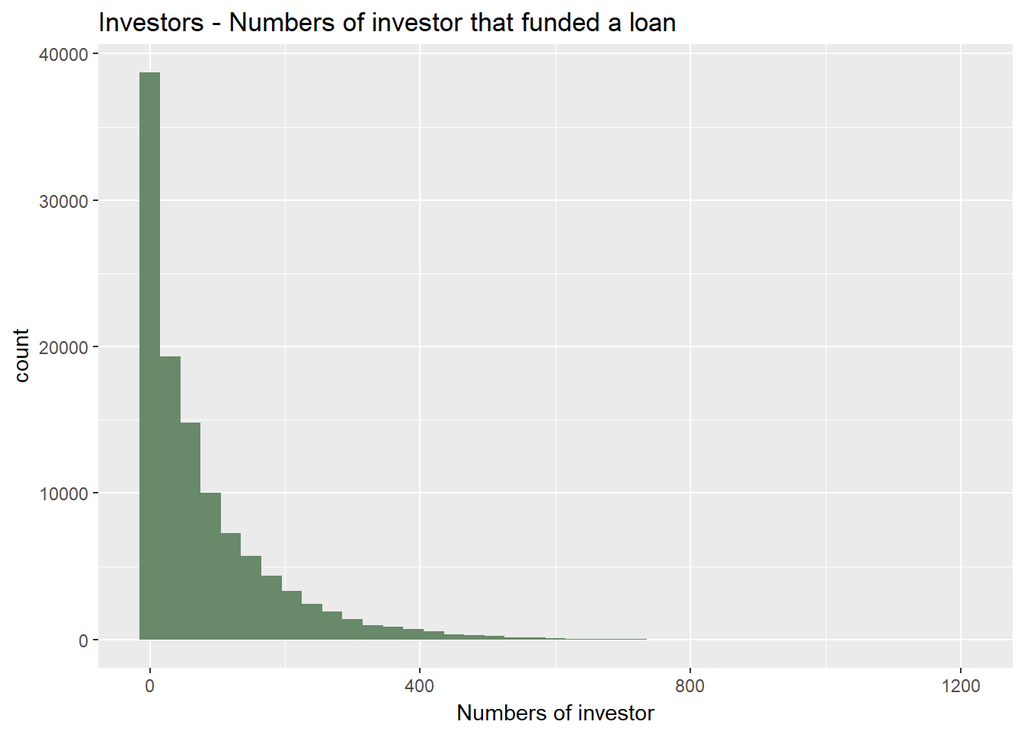

Figure 1 - Numbers of investors.

The figure 1 show a positive skew distribution with a long tail from the numbers of investors. It clarify the most part of the loan is formed by few investors. Frequently, a loan is funded by just one investor.

After July 2009, the estimatives estimated effective yield, estimated loss and estimated return was added to the dataset which allow us to analyze the risk to fund a loan.

Effective yield is equal to the borrower interest rate minus the servicing fee rate, minus estimated uncollected interest on charge-offs, plus estimated collected late fees. The estimated loss is the estimated principal loss on charge-offs.

The next figure show the distribution from the estimated loss and effective yield in percentage .

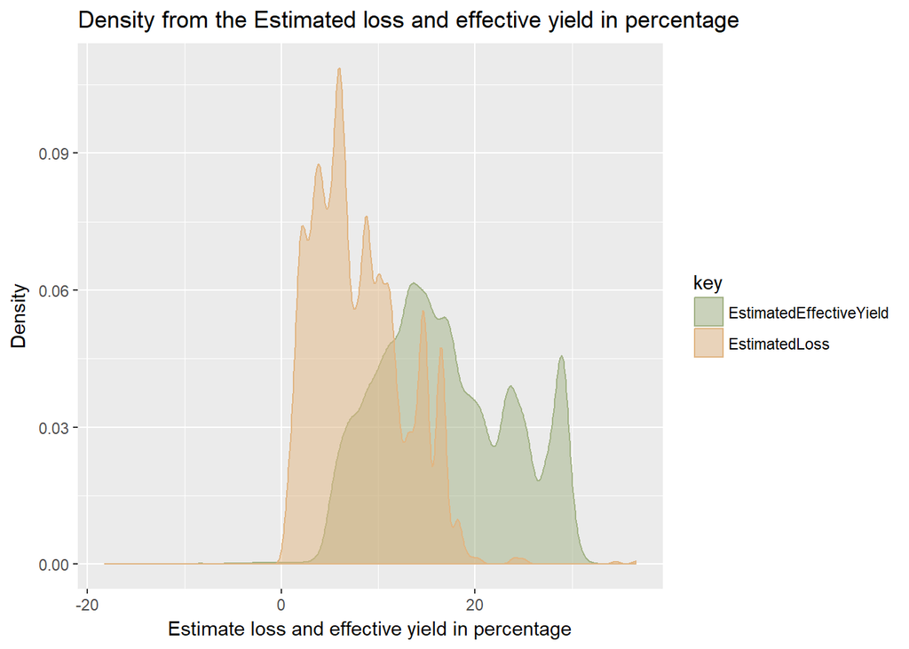

Figure 2 - Density from the Estimated loss and effective yield in percentage.

The figure 2 shows both estimated loss and effective yield in percentage in the same plot. Both variables show multimodal distribution. The effective yield covers a larger positive area from the plot than the estimate loss, what means it is more likely it get an effective yield greater than estimated loss. On average, the estimated loss is 8.03% and the effective yield is 16.87.

Estimated return show us the difference between Estimated Effective Yield and the Estimated Loss Rate.

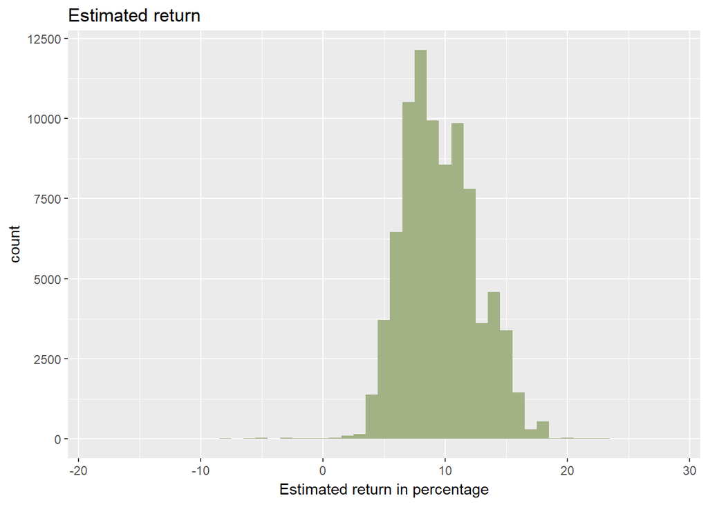

Figure 3 - Estimated return in percentage.

The estimated return is a normal distribution. The average return is around 9.61%.  
Analyzing the estimated return distribution, it is a normal distribution with frequenty values in the positive area from the plot what means it is likely the investor will have a positive return from their investiment. The minimun is -18.27 and it is not superior to 28.37 percent by year and 50% of the loan has estimated return varying from 7.408% to 11.66%.

### Loan

A loan is the lending of money from one individual, organization or entity to another individual, organization or entity at an interest rate.

The next plot show the distribution from the number of loans by year.

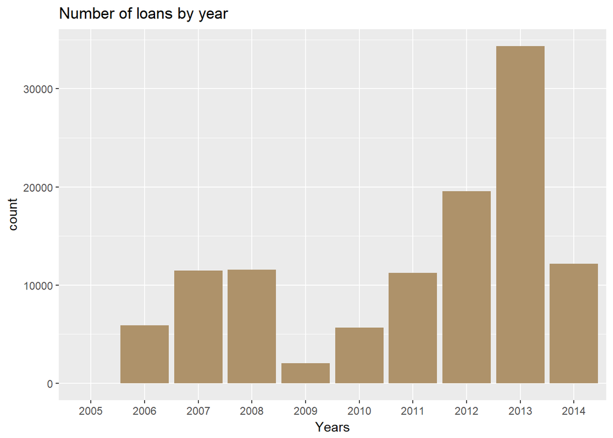

According the figure 4, from 2009 to 2013, the amount of loans has strongly increases and in. In 2014, the data was collected until March, consequently there is sharp fall.

It shows the confidence the investors have in this business, though, it is a risky investiment.

The next figure shows the distribution from LoanOriginalAmoung variable.

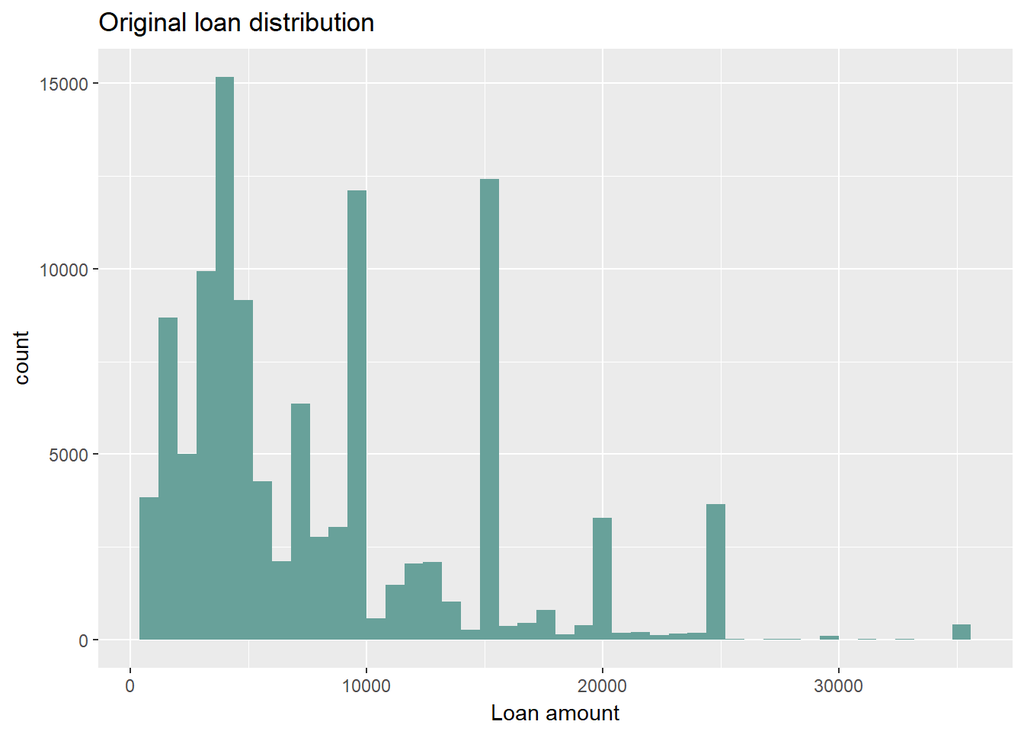

Figure 5 - Original loan amount distribution.

### Credit managment.

Credit score as provided by a consumer credit rating agency. The dataset has the lower and the upper credit score value.

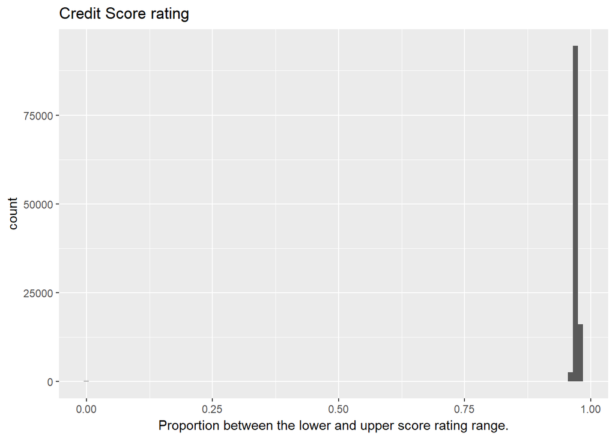

Figure 5 - Proportion between the lower and upper score rating range.

The upper and the lower value is very close when the division from the lower value by the upper value is near to 1, as shown in the figure 5.

Applying the log 10, the comprehension from the distribution is better.

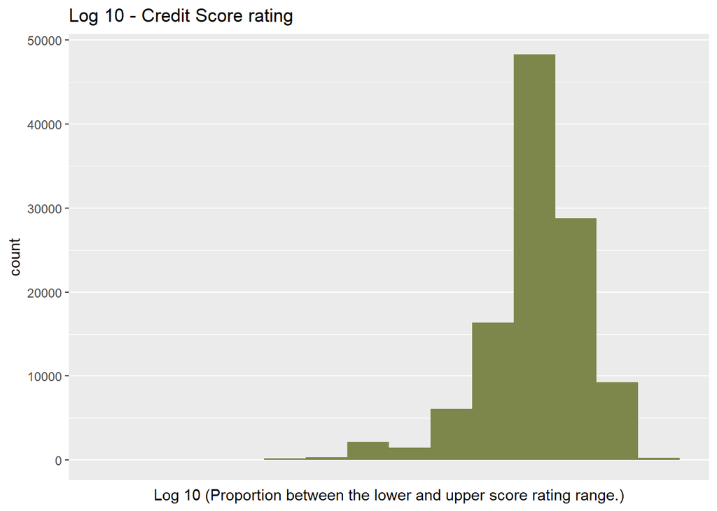

Figure 6 - Log 10 - Credit Score rating

The distribution has a negative skewness what means the most frequent values go to 1 direction, what confirm the difference from the upper and lower credit range score has slight variations.

The next plot show the Credit score range upper distribution.

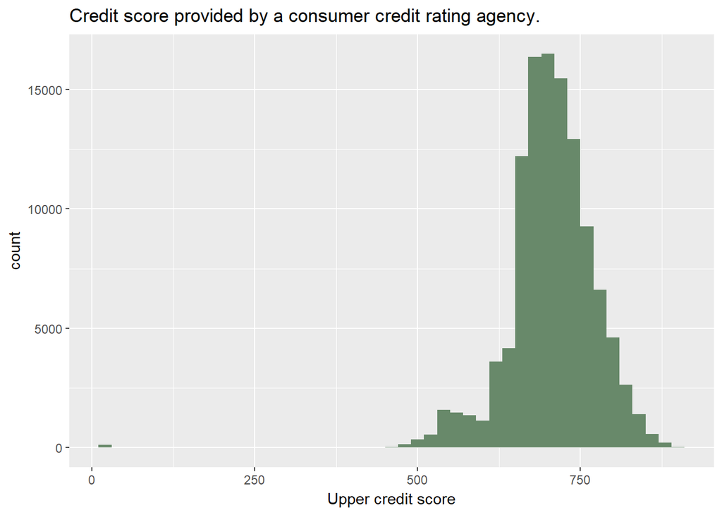

Figure 7 - Credit score provided by a consumer credit rating agency

The distribution from the upper credit score rating shows a interval confidence from 95% varying from 599 to 779.

After 2009, Prosper company built its custom risk using historical proper data. The score ranges from 1-10, with 10 being the best, or lowest risk score.

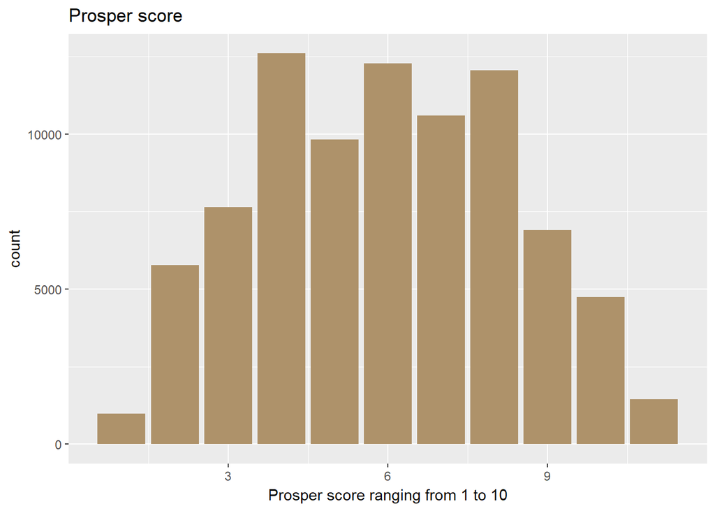

Figure 8 - Prosper score

The prosper data shows the score range from 1 to 10, however there are some input with score 11, therefore, the next plort are going to disregard the score 11.

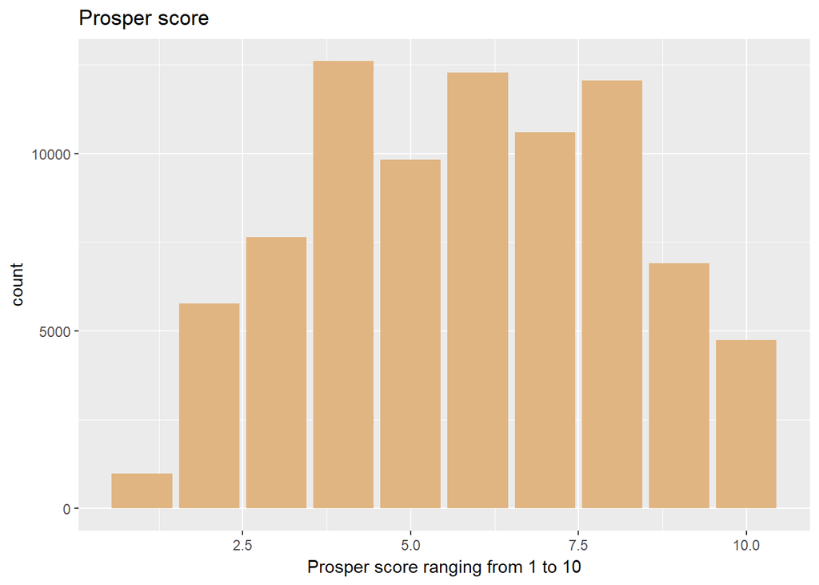

Figure 9 - Prosper score

According the prosper score distribution the most frequent loans are available for score 4, 6 and 8 what means the loans risk is often intermediate.

For loans after 2009, a prosper rating was assigned at the moment the listing was created and its possible values are: 1 - HR, 2 - E, 3 - D, 4 - C, 5 - B, 6 - A, 7 - AA. Each loan is assigned a rating from AA (lower risk, lower return) to HR (higher risk, higher return)[6].

The next plot show the distribtuion.

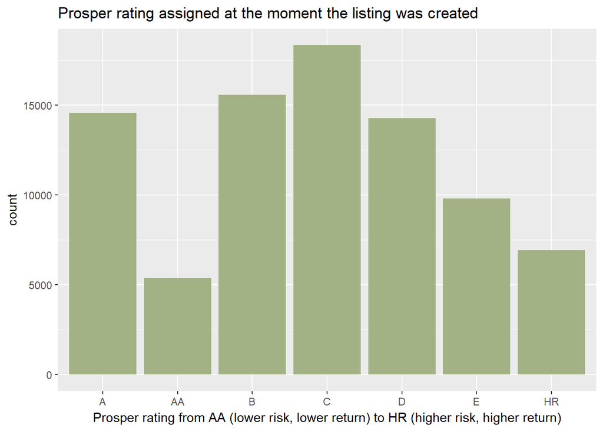

Figure 10 - Prosper rating assigned at the moment the listing was created

Figure 10 shows the most frequenty values are intermediate, a very similar distribution shown in the figure 9.

### Term

The length of the loan expressed in months. Short-term is an investment you expect to hold for 3 years or less [2]. The next table shows the terms are 12, 36, and 60 months, and the most frequent term is 36 months, what means for a investor is a short term investment.

```
## # A tibble: 3 x 2
##    Term     n
##   <int> <int>
## 1    12  1614
## 2    36 87778
## 3    60 24545
```

Table 1 - Length of the loan expressed in months by number of observations.

### Income

Income is the money that the borrower receives in exchange for providing a good or service[3]. The Prosper dataset store the income range of the borrower at the time the listing was created and the income verifiable to indicate the borrower have the requirement documentation to support their income.

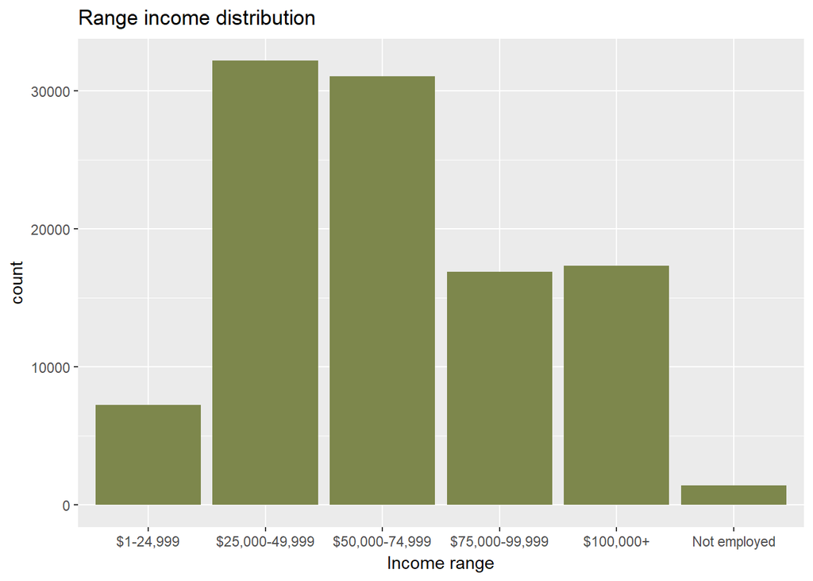

Figura 11 - Income range distribution.

The income from the most part of the borrower vary from 25,000 to 74,999, according the figure 11. The dataset also shows, 92.39% has document to support their income.

Analyzing the impcat the loan has in their income, Prosper dataset has the Debt to income ration. A debt income ratio (often abbreviated DTI) is the percentage of a consumer’s monthly gross income that goes toward paying debts[7].

The next plot will show DTI distribution.

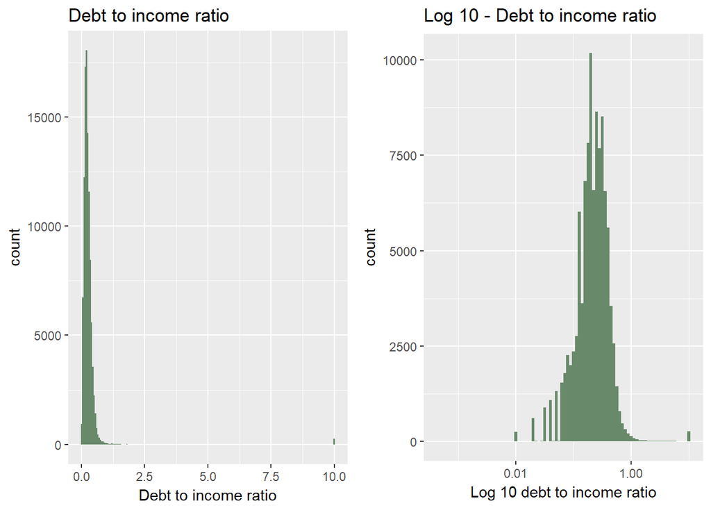

Figura 12 - Debt to income ratio

For the debt to income ration, the higher the value the greater is the risk. According left plot in the figure 12, the concentration of the value is not higher than 1, what means the monthly salary is close to the loan. After applying log 10 to x axis, a negative skewed distribution is shown, as in the right plot in the figure 12.

# Univariate Analysis

### What is/are the main feature(s) of interest in your dataset?

The investiment risk. This investiments can represent risk for the investor and also good returns. The main interest is to use the data to understand the risk to fund a loan.

### What other features in the dataset do you think will help your investigation into your features of interest?

The features are going to help to investigate the feature of interest are: The income range, estimated return, estimated loss, prosper score, prosper rating, credit score range and credit score.

### Did you create any new variables from existing variables in the dataset?

Yes, year and month year the loan originated data.

### Of the features you investigated, were there any unusual distributions? Did you perform any operations on the data to tidy, adjust, or change the form of the data? If so, why did you do this?

Yes, credit score rating, original loan distribution , debt to income ration. I perform a log 10 to credit score rating, debt to income ration to adjust the data.

# Bivariate Analysis

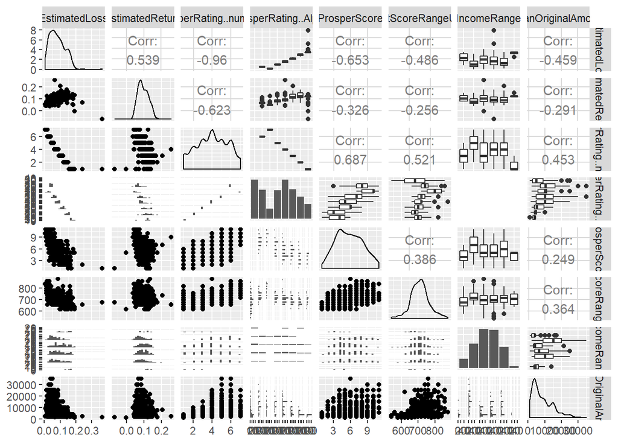

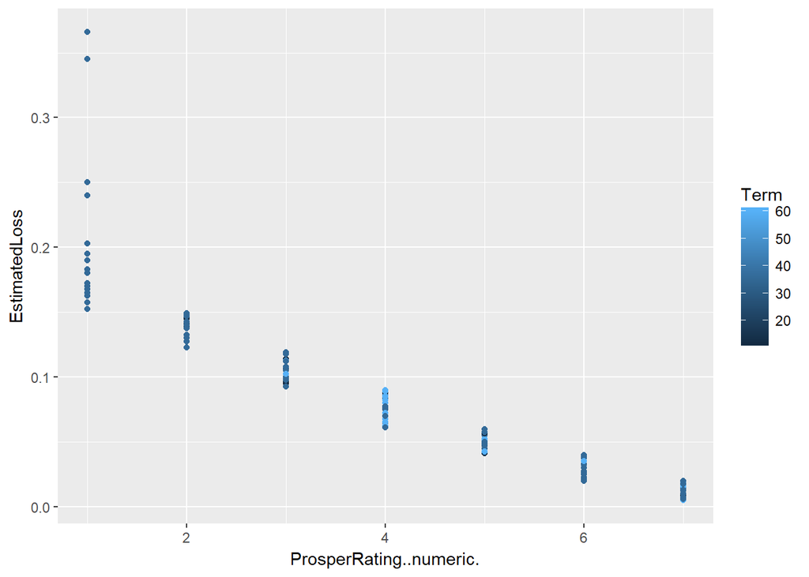

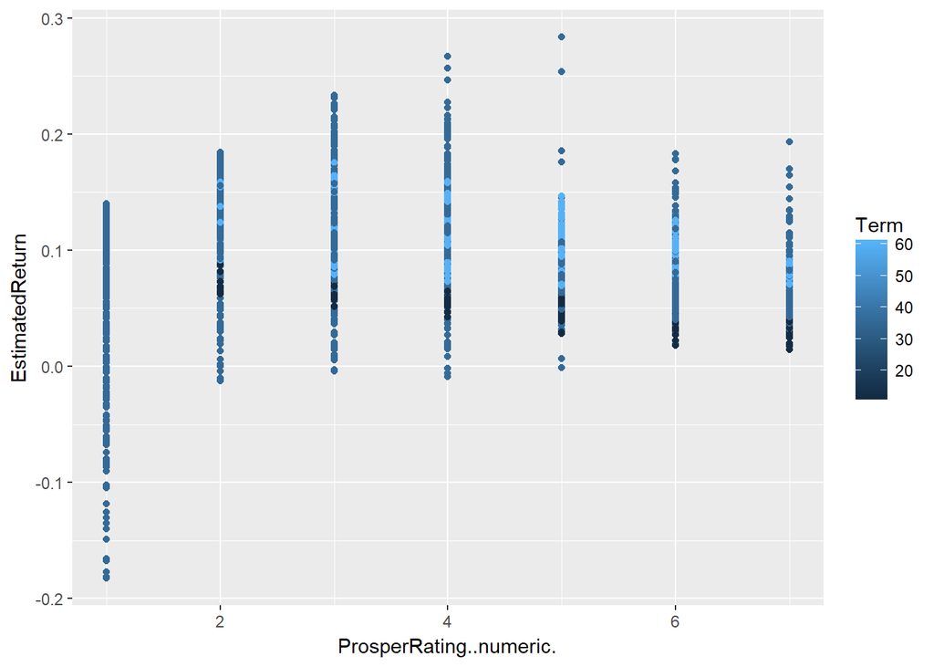

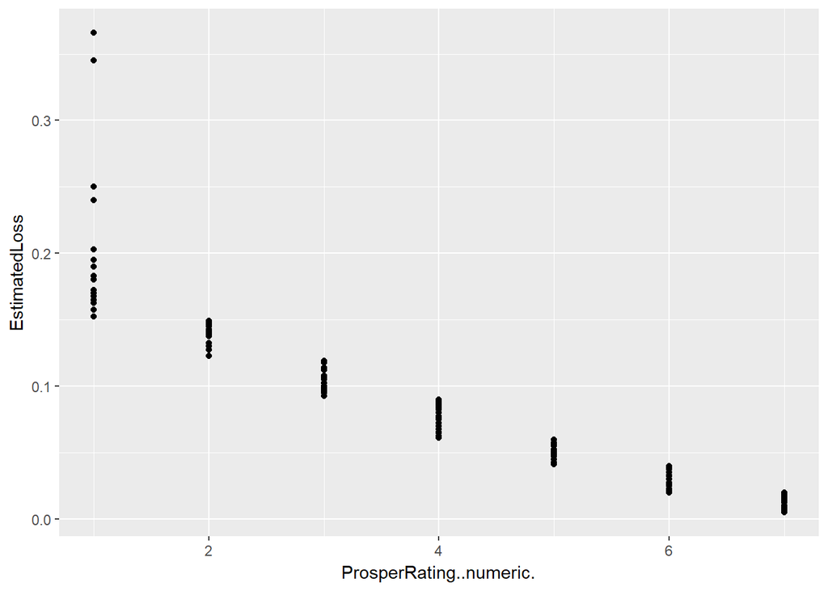

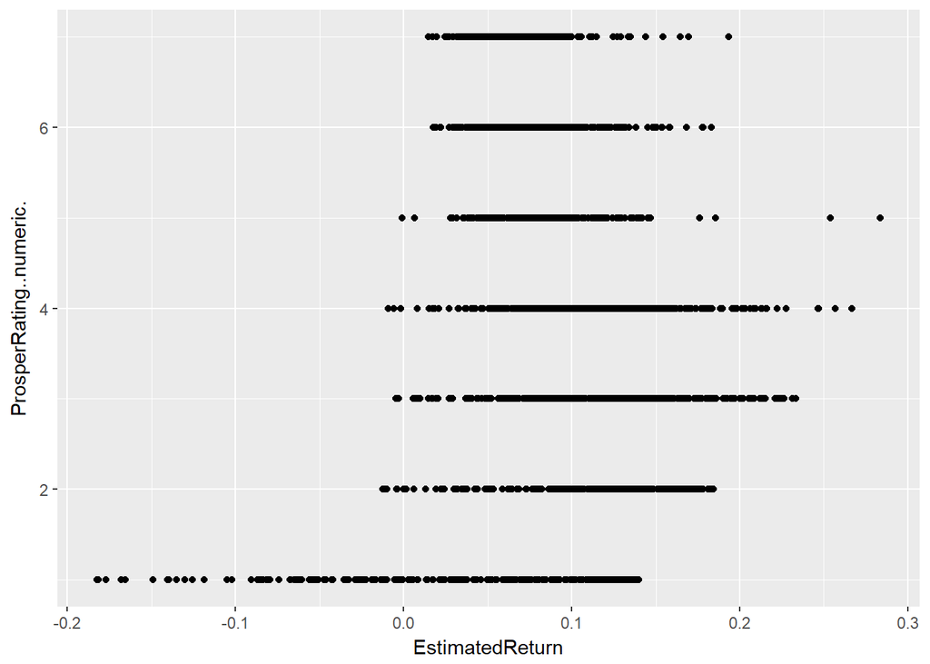

The most borrower tax, the higher estimated loss.

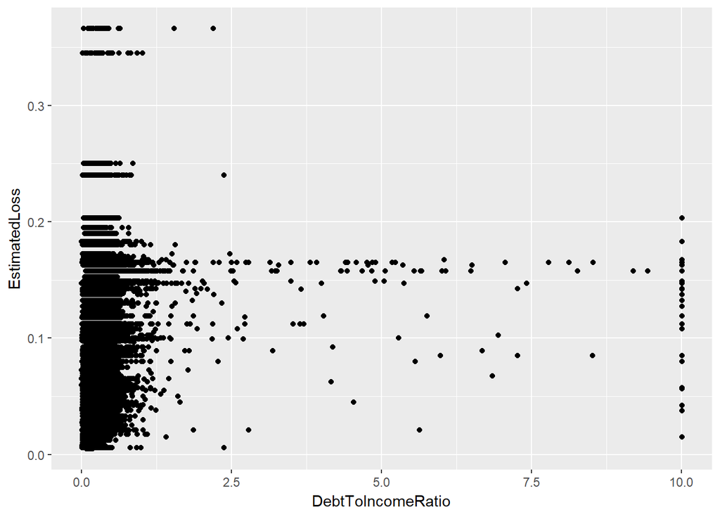

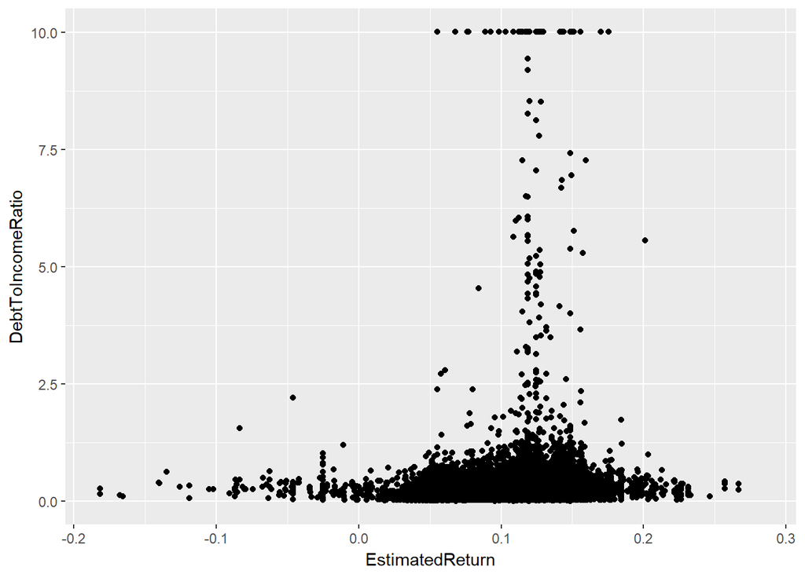

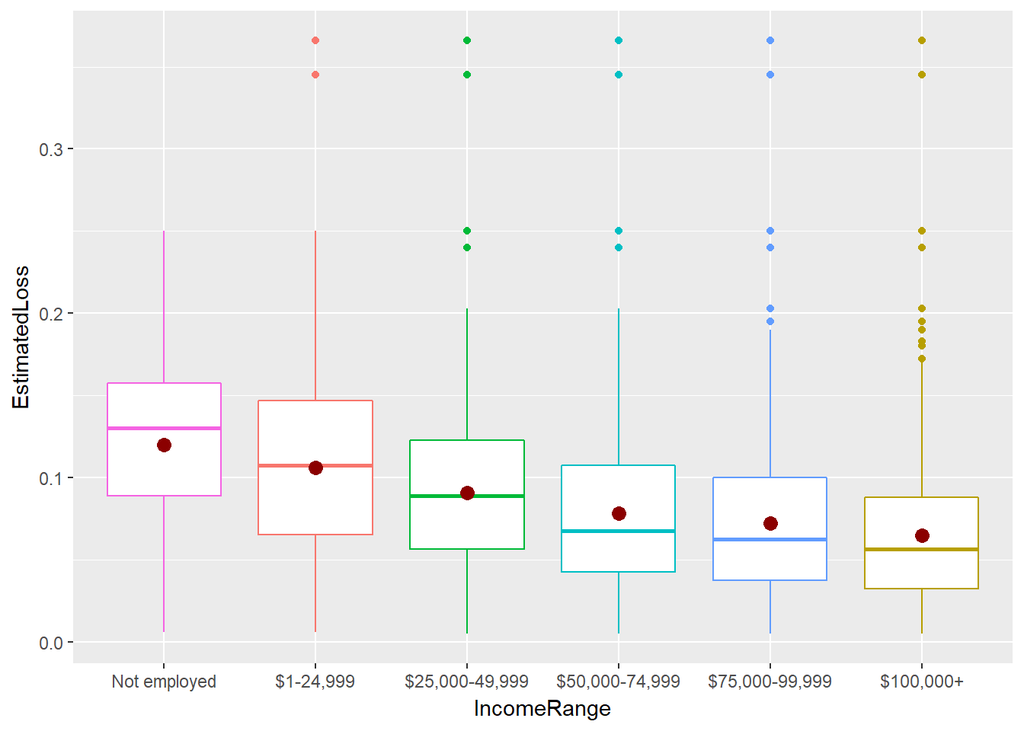

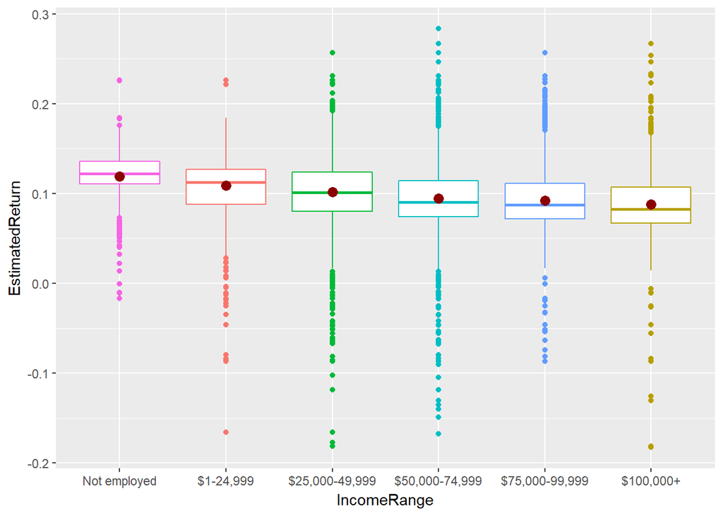

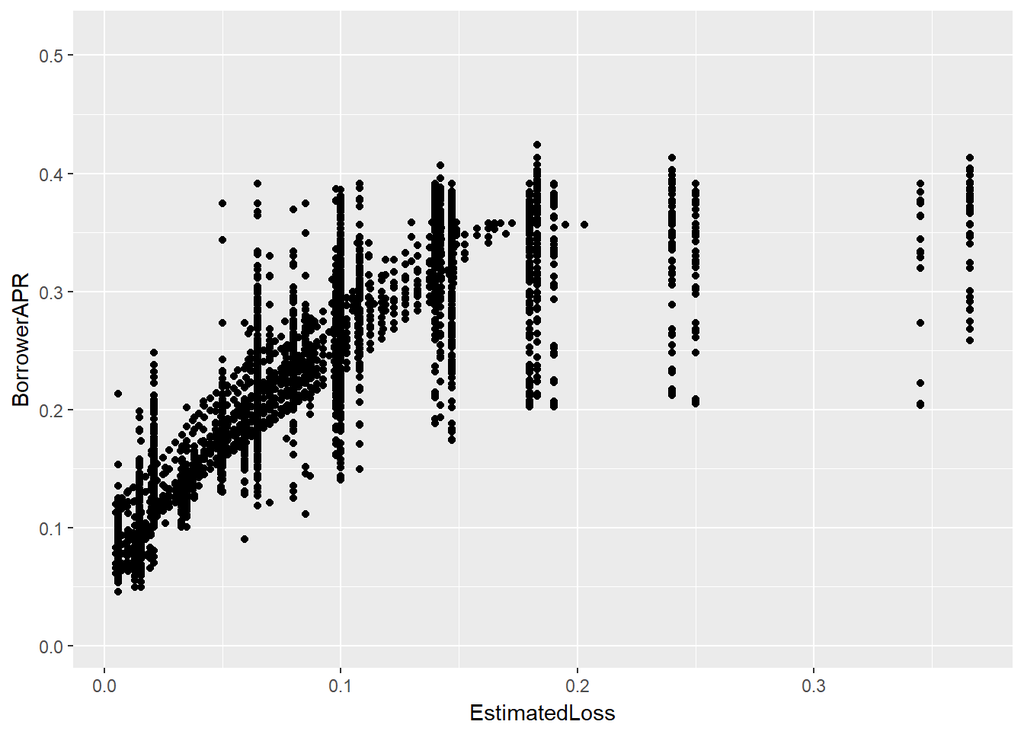

[1]https://en.wikipedia.org/wiki/Loan [2]https://www.thebalance.com/are-long-term-or-short-term-investments-better-2385918 [3]https://www.investopedia.com/terms/i/income.asp#ixzz58PVUEsPQ [4]http://www.lendingmemo.com/prosper-loan-complaints/ [5]https://www.investopedia.com/terms/d/delinquency-rate.asp [6]https://www.prosper.com/invest [7]https://en.wikipedia.org/wiki/Debt-to-income_ratio